# Writing Custom Functions in RTMB

## Write a Custom Distribution

- If `RTMB` doesn’t have the distribution you want
- Check `RTMBdist` for additional distributions
- Still want their simulation functionality
- Can write a special function that RTMB will recognize for simulation

## Example Logit Normal Distribution

- Consider a probability $p$, such that

$$\text{logit}(p) \sim N(\mu, \sigma)$$
- What is the distribution of $p$?

- We need to take into account the distortion caused by the transform

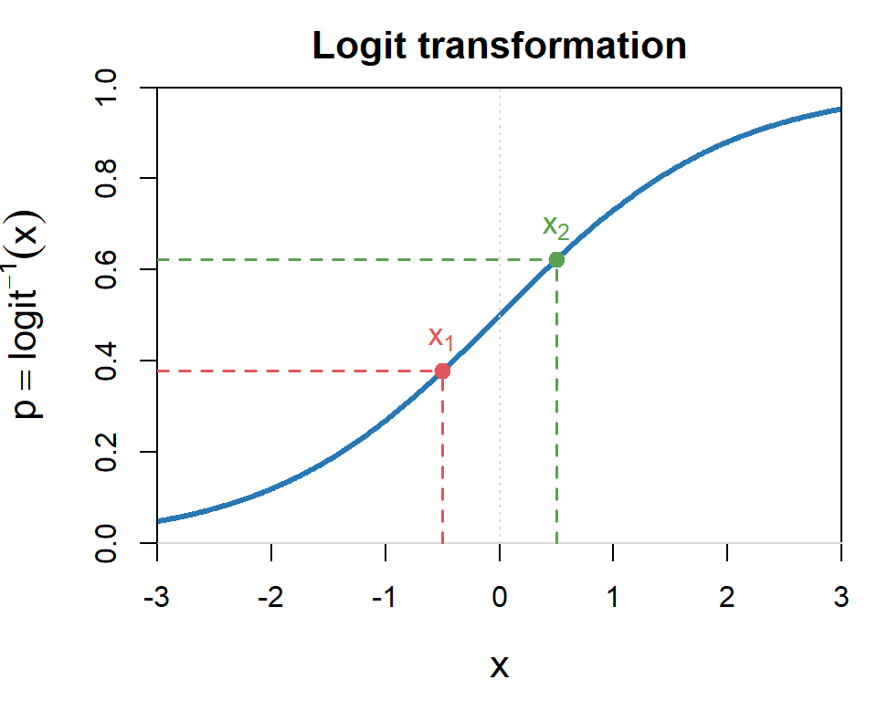

## Logit Normal Distribution

- That change is defined based on the Jacobian.
- For a `logit`, the inverse is

$$\text{logit}^{-1}(x) = p = \frac{\exp(x)}{1+\exp(x)}$$

- The determinant of the Jacobian (in 1D absolute value of derivative)

$$|\frac{g(p)}{dp}| = p(1-p)$$

- The other direction, it is just the inverse, $\frac{1}{p(1-p)}$
- The distribution of $p$, is then

$$f(p) = \frac{1}{p(1-p)}N(\text{logit}(p), \mu,\sigma)$$

- Through simulation we can confirm

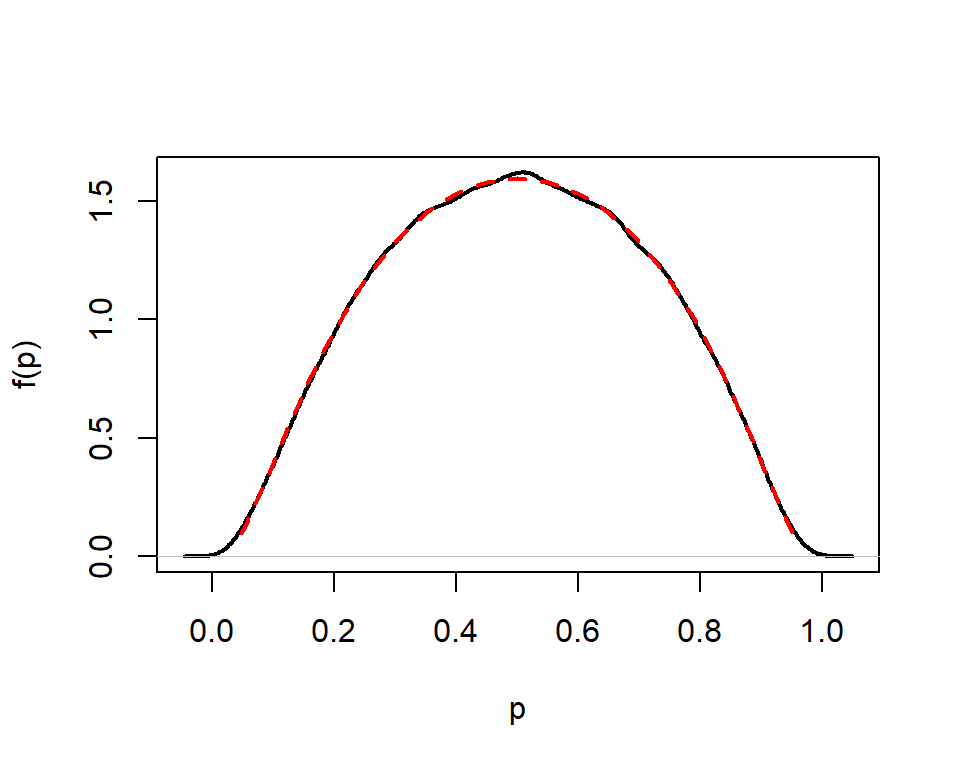

## Log Normal Distribution

- Compare logging the data first as opposed to declaring it log-normal.
- Let’s just look at Chilko sockeye stock recruit.
- For $\log(x) = y$, absolute value of derivative is $1/x$, and $y$ is normally distributed.

```r
library(RTMB)

soxch <- sox %>% filter(PopName == "Chilko")

dlognorm <- function(x, mean, sd, log = FALSE){
  y <- log(x)
  logpdens <- dnorm(y, mean, sd, log = TRUE) - y # -y == log(1/x)

  if (inherits(x, "simref")) {
    return(RTMB:::dGenericSim(
      "dlognorm",
      x = x,
      mean = mean,
      sd = sd,
      log = log
    ))
  }

  if(log) return(logpdens)
  return(exp(logpdens))
}

rlognorm <- function(n, mean, sd){
  exp(rnorm(n, mean, sd))
}
```

## Log Normal Distribution Cont…

- Does it matter if I include the Jacobian for my observed distribution?

```r
param <- list(logsigma = 0, alpha = 0, logbeta = 0)
soxch$RS <- soxch$recruits/soxch$spawners

negll <- function(pars){
  getAll(pars, soxch)
  mu <- alpha - exp(logbeta)*spawners
  sigma <- exp(logsigma)
  RS <- OBS(RS)

  if(lognormal == TRUE){
    nll <- -sum(dlognorm(RS, mu, sigma, log = TRUE))
  }else{
    nll <- -sum(dnorm(log(RS), mu, sigma, log = TRUE))
  }
  return(nll)
}

lognormal <- TRUE
obj <- MakeADFun(negll, param, silent = TRUE)
# obj$fn()

lognormal <- FALSE
obj2 <- MakeADFun(negll, param, silent = TRUE)
# obj2$fn()
```

## Checking Simulation

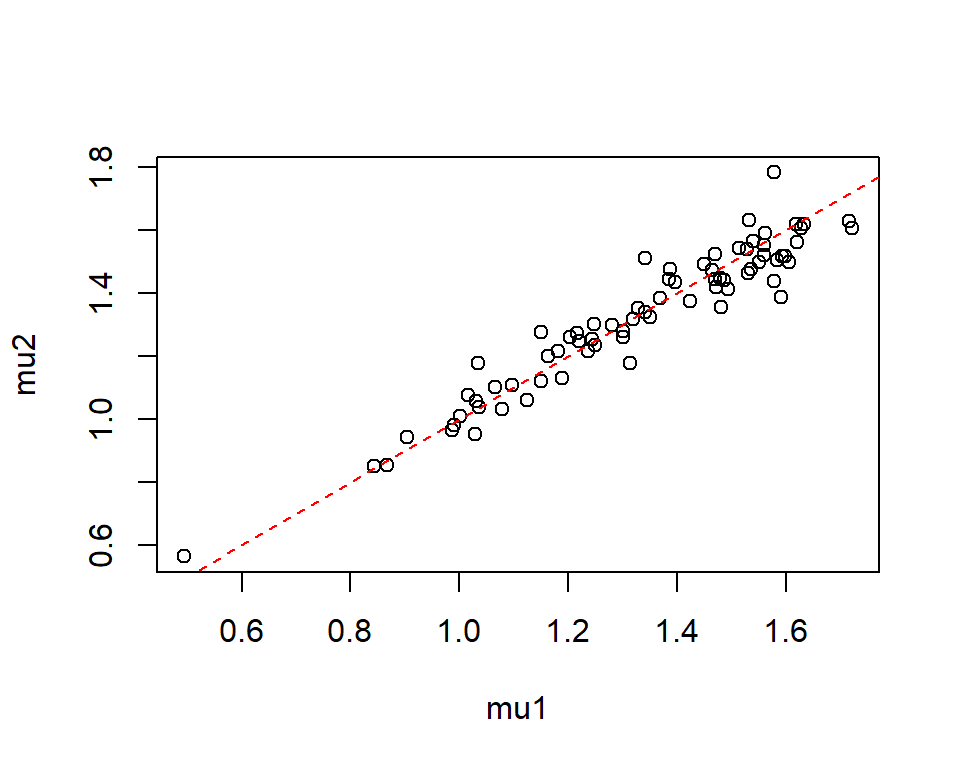

```r
sim1 <- sapply(1:1000, FUN = function(x){obj$simulate()$RS})
mu1 <- apply(sim1, 1, mean)

sim2 <- sapply(1:1000, FUN = function(x){obj2$simulate()$RS})
mu2 <- apply(sim2, 1, mean)

plot(mu1, mu2)
abline(0, 1, col = 'red', lty = 2)
```

## When it Matters

- When a Bayesian it is really important (prior distributions)
- Non-normal random effects in a Frequentist perspective
- Consider a Poisson count that depends on a random effect
- If gamma distributed, then that becomes a negative-binomial

$$\begin{align}
\exp(x) & \sim \text{gamma}(a,b) \\
x & \sim \text{gamma}(\exp(x), a, b)\exp(x)
\end{align}$$

```r
dlgamma <- function(x, shape, rate, log = FALSE){
  y <- exp(x)
  logpdens <- dgamma(y, shape = shape, rate = rate, log = TRUE) + x

  if(log) return(logpdens)
  return(exp(logpdens))
}

lambda <- rgamma(100, 5, 1)
count <- rpois(100, lambda)

param <- list(logshape = 0, lograte = 0, logre = numeric(100))

negll <- function(pars){
  getAll(pars)
  a <- exp(logshape)
  b <- exp(lograte)

  nll <- 0
  if(nb == TRUE){
    nll <- nll - sum(dnbinom(count, a, b/(1+b), log = TRUE))
  }else{
    mu <- exp(logre)
    if(lgamma == TRUE){
      nll <- nll - sum(dlgamma(logre, a, b, log = TRUE))
    }else{
      nll <- nll - sum(dgamma(mu, a, b, log = TRUE))
    }
    nll <- nll - sum(dpois(count, mu, log = TRUE))
  }
  return(nll)
}

lgamma <- TRUE
nb <- FALSE
obj <- MakeADFun(negll, param, random = "logre", silent = TRUE)
# obj$fn()

lgamma <- FALSE
obj2 <- MakeADFun(negll, param, random = "logre", silent = TRUE)
# obj2$fn()

nb <- TRUE
obj3 <- MakeADFun(negll, list(logshape = 0, lograte = 0), silent = TRUE)
# obj3$fn()
```

## ADjoint

- Sometimes gradients are slow to compute via AD
- Can be much more efficient than taping to pass the known gradient to RTMB
- In these cases RTMB has `ADjoint` that allows you to provide the function and gradient.
- `ADjoint` Accepts the function eval, `f` and then the gradient `df` as second argument.
- A gradient should have three inputs
  - `x` the input for `f`
  - `y` the output for `f`
  - `dy` the reverse mode derivative that RTMB carries, which is needed for the chain rule
- The `dy` term ensures that the given derivative is passed into the tape.

```r
xsq <- ADjoint(
  \(x){x^2},
  \(x, y, dy){dy*2*x}
)
F <- MakeTape(\(x)log(xsq(x)), 3)
F(3)  ## log(3^2)
```

```
[1] 2.197225
```

```r
F$jacobian(3)   ## 2*3/(3^2)
```

```
          [,1]
[1,] 0.6666667
```

## Lambert W Example

- Lambert W function is computed by approximation, but has an analytical gradient.

$$W(x)e^{W(x)} = x$$

- In this case,

$$\frac{dW(x)}{dx} = \frac{1}{e^{W(x)}(1+W(x))}$$

- Here $W(x)$ is the output of the call to Lambert W, or $y$ for the gradient.

```r
## Numerical Solution (don't worry about it)
W <- function(x) {
  logx <- log(x)
  y <- pmax(logx, 0)
  while (any(abs(logx - log(y) - y) > 1e-9, na.rm = TRUE)) {
      y <- y - (y - exp(logx - y)) / (1 + y)
  }
  y
}
## Derivatives (y = W(x), dy is internal RTMB gradient.)
dW <- function(x, y, dy) {
   dy / (exp(y) * (1 + y))
}
## Define new derivative symbol
LamW <- ADjoint(W, dW)

## Can now use LamW in your own code!
F <- MakeTape(function(x)sum(LamW(x)), numeric(3))
```

## Multivariate Logit Normal

- Consider a vector $\mathbf{p}$, such that if we transform it with a multivariate logit,

$$\text{mlogit}(\mathbf{p}) \sim N(\boldsymbol{\mu}, \Sigma).$$

- We might want to do something like this for proportions that are correlated, often for age class data.

```r
## Transformation:
mlogit <- \(x){
  n <- length(x)
  log(x[-n]/x[n])
}
imlogit <- \(x){
  ex <- exp(c(x,0))
  ex/sum(ex)
}

## ADjoint for determinant
logdet <- ADjoint(
  function(J) {
    determinant(J, logarithm = TRUE)$modulus
  },
  function(J, y, dy) {
    t(solve(J)) * dy
  },
  name = "logdet"
)

# Log absolute determinant of Jacobian using MakeTape
mlogit_logdet <- function(x) {

  n <- length(x)
  tape <- MakeTape(\(x) mlogit(x), x)
  J <- tape$jacobian(x)
  logdet(J[1:(n-1), 1:(n-1)])
}


mu <- c(-1, 1)
Sigma <- matrix(c(0.25, -0.1, -0.1, 0.5), nrow=2, ncol=2)
x <- MASS::mvrnorm(1, mu, Sigma)
p <- imlogit(x)
```